# lumber strength report

Yunfeng Yang

2023-06-07

# Damage model

The original model is

$$\begin{equation}\label{eq: original
model}
y^* = y \cdot I\{c \cdot y > l\} + \alpha \cdot y \cdot I\{c \cdot y
< l\}
\end{equation}$$

# Smooth function

Note that we have the indicator function in the model we might consider the smooth function:
$$\begin{equation}\label{eq: trans function}
S(x;s) = \frac{1}{1 + \exp(-s \cdot x)}
\end{equation}$$
, where $s$ is the smoothing hyper-parameter to control the smoothness.

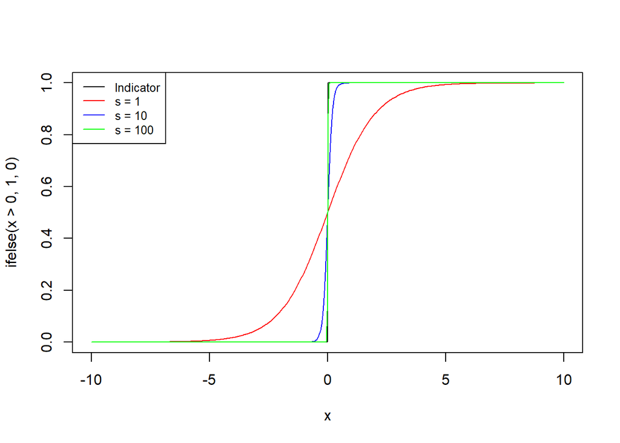

```r
smooth_ind <- function(x,s){
  return(1/(1+exp(-x*s)))
}
x <- seq(from = -10, to= 10, length.out = 500)
plot(x,ifelse(x>0,1,0),type = "l")
lines(x,sapply(x,smooth_ind, s = 1),type = "l",col = "red")
lines(x,sapply(x,smooth_ind, s = 10),type = "l",col = "blue")
lines(x,sapply(x,smooth_ind, s = 100),type = "l",col = "green")
legend("topleft", legend=c("Indicator", "s = 1", "s = 10", "s = 100"),
       col=c("black","red", "blue","green"), lty=1, cex=0.8)
```

Then the model becomes
$$y^* = y \cdot \frac{1}{1 + \exp(-s\cdot(cy-l))} + \alpha \cdot y \cdot
\frac{1}{1 + \exp(-s\cdot(l-cy))}$$
# the plot

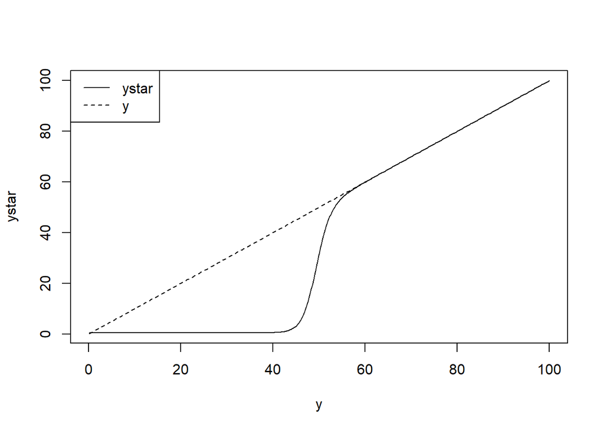

```r
### new

mu <- 48
sigma <- 19
#y <- rnorm(N,mean = mu, sd = sigma)
y <- seq(from = 0.1, to = 100, length = 500)
l <-  32
alpha <- 0.45
c <- 0.65
s <- 1
ystar <- y*smooth_ind(c*y-l,s )+ alpha*smooth_ind(l-c*y,s)

plot(y,ystar,type = 'l',lty = 1)
lines(y,y,lty = 2)
legend("topleft", legend = c("ystar","y"),lty=1:2)
```

We have $y \geq y^*$.

The lumber have three groups:

- Group 1: $y <l$, $y^* < l$, i.e., $y^* <y < l$. The lumber pieces are broken blow the proof loading.
- Group 2: $y >l$, $y^* < l$, i.e. $y^*<l<y$. The lumber pieces are broken during the proof loading process. This groups we only knows how many pieces.
- Group 3: $y >l$, $y^* > l$, i.e. $l<y^*<y$. The lumber pieces survived in the proof-loading. And then we destruct them to test their strength.

# The PDF calculation

Given $Y \sim N(\mu, \sigma^2)$, $Y^* = h(Y)$. Then the pdf of $Y^*$,
$$f_{Y^*}(y^*) = f_{Y}(h^{-1}(y^*))|\frac{d}{dy^*}h^{-1}(y^*)|,$$
where $f_Y()$ is the pdf of $Y$, i.e., normal.

Following this, We need the numerical function of $h^{-1}(y^*)$, and its numerical gradient $\frac{d}{dy^*}h^{-1}(y^*)$. (The analytical form doesn’t seem available.)

```r
#' The smooth function for the indicator function, which is also called "sigmoid function".
#'
#' @param x, the variable
#' @param s, the hyper parameter, higher s means closer the indicator function
#' @returns the smoothed value.

smooth_ind <- function(x,s){
  return(1/(1+exp(-x*s)))
}



#' The damage model, smoothed version of
#' "y* = y* I(c*x > l) + alpha * y * I(c*x < l)"
#'
#' @param y, the original strength
#' @param alpha, the damage parameter
#' @param l, the proof loading level
#' @param c, the threshold parameter. Damage effects happen exceeding c.
#' @param s, the temperature parameter for s
#' @return, the weakened y*, y*<y.
dmg_model <- function(y,alpha,l,c,s){
  return(y*smooth_ind(c*y-l,s)+ alpha*y*smooth_ind(l-c*y,s))
}

#' The damage-inverse model, given a weakened ystar, find the original y
#'
#' @param ystar, the weakened strength
#' @param alpha, the damage parameter
#' @param l, the proof loading level
#' @param c, the threshold parameter. Damage effects happen exceeding c.
#' @param s, the temperature parameter for s
#' @return, the original y, y>y*.
dmg_inverse <- function(ystar,alpha,l,c,s){
  uniroot((function (x) dmg_model(x,alpha,l,c,s) - ystar), lower = 0, upper = 1000)$root
}
# the abs gradient at damage-inverse
dmg_inverse_grad <- function(ystar,alpha,l,c,s){
  abs(numDeriv::grad(func = (function(x) dmg_inverse(x,alpha,l,c,s)),
                     x  = ystar))
}
# dmg_inverse_grad(42,a lpha,l,c,s)
# ystar <- y*smooth_ind(c*y-l)+ alpha*smooth_ind(l-c*y)

dmglik <- function(ystar,alpha,l,c,s,mu,sigma){
  y <- dmg_inverse(ystar,alpha,l,c,s)
  dnorm(y, mean = mu, sd = sigma, log = TRUE)+ log(dmg_inverse_grad(ystar,alpha,l,c,s))
}
```

```r
## plot
set.seed(8888)
# the orignal sample size
N <- 300
mu <- 48
sigma <- 19
#y <- rnorm(N,mean = mu, sd = sigma)
l <-  32
# alpha <- 0.9
# c <- 0.8
alpha <- 0.45
c <- 0.65
s <- 1

## data

y <- rnorm(N, mean = mu, sd = sigma )
y <- y[y>0]
y_obs <- list()
# group 1, y^* <y < l
y_obs$group1 <- y[which(y < l)]
# group 2, y^*<l<y
group23 <- y[which(y > l)]
group23_star <- dmg_model(group23,alpha,l,c,s)
y_obs$group2 <- length(group23[which(group23 > l &group23_star < l)])
y_obs$group3 <- group23_star[which(group23_star >l)]

negdmglik_model <- function(theta){
  mu <- theta[1]
  sigma <- theta[2]
  alpha <- theta[3]
  c <- theta[4]

  lik1 <- sum(dnorm(y_obs$group1,mean = mu, sd = sigma, log = TRUE))
  lik2 <- y_obs$group2 * log(
    pnorm(dmg_inverse(l,alpha,l,c,s), mean = mu, sd = sigma) -
      pnorm(l, mean = mu, sd = sigma)
  )
  #lik2 <- 0
  lik3 <- sum(sapply(y_obs$group3,dmglik,alpha,l,c,s,mu,sigma))
  return(-lik1-lik2-lik3)
  #return (-lik3)
}

theta0 <- c(mu,sigma,alpha,c)
```

```r
optimout <- optim(theta0,negdmglik_model,method = "L-BFGS-B",
                  lower = rep(0.1,4),upper = c(Inf,Inf,1,Inf))

# theta0 is true theta
rbind(theta0,optimout$par)
```

```
##            [,1]     [,2]      [,3]      [,4]
## theta0 48.00000 19.00000 0.4500000 0.6500000
##        47.99939 19.00907 0.4435964 0.6394996
```

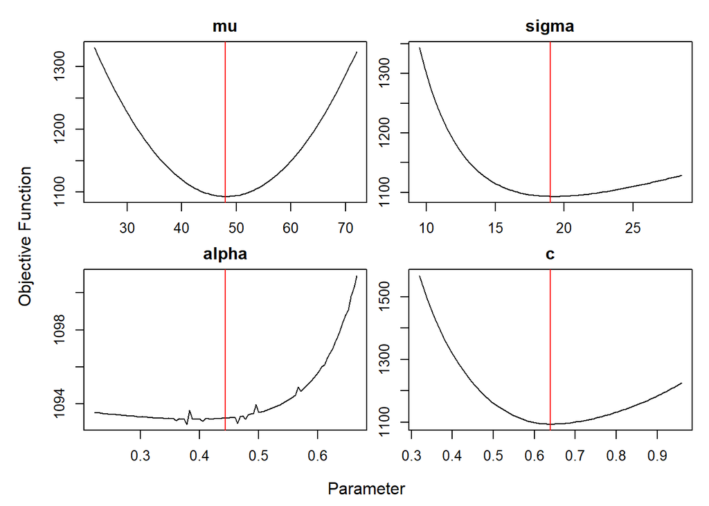

```r
optimCheck::optim_proj(optimout$par,
                       negdmglik_model,xrng = .5,
                       xnames = c("mu","sigma","alpha","c"))
```

# Real data analysis

In this section, we apply the damage model to the real dataset.

I also used the logit and expit transformation to map the damage effect parameter $\alpha$ (0,1) to R for convenience transformation.

```r
bending <- read.csv("bending-pl.csv", header = T)

bending[,1] <- bending[,1]/1000*6.895
l <- 4500/1000*6.895
# bending_mar <- bending[1:195,]
# bending_dmg <- bending[195:341,]

R100_data <- bending[bending[,2] == "R100",1]
R20_data <- bending[bending[,2] == "R20",1]
R20R100_data <- bending[bending[,2] == "R20R100",1]

# 97 pieces breaking in the loading process.
g2 <- 97
mu <- 48
sigma <- 19

s <- 1
```

```r
#' The smooth function for the indicator function, which is also called "sigmoid function".
#'
#' @param x, the variable
#' @param s, the hyper parameter, higher s means closer the indicator function
#' @returns the smoothed value.

smooth_ind <- function(x,s){
  return(1/(1+exp(-x*s)))
}



#' The damage model, smoothed version of
#' "y* = y* I(c*x > l) + alpha * y * I(c*x < l)"
#'
#' @param y, the original strength
#' @param alpha, the damage parameter
#' @param l, the proof loading level
#' @param c, the threshold parameter. Damage effects happen exceeding c.
#' @param s, the temperature parameter for s
#' @return, the weakened y*, y*<y.
dmg_model <- function(y,alpha,l,c,s){
  return(y*smooth_ind(c*y-l,s)+ alpha*y*smooth_ind(l-c*y,s))
}

#' The damage-inverse model, given a weakened ystar, find the original y
#'
#' @param ystar, the weakened strength
#' @param alpha, the damage parameter
#' @param l, the proof loading level
#' @param c, the threshold parameter. Damage effects happen exceeding c.
#' @param s, the temperature parameter for s
#' @return, the original y, y>y*.
dmg_inverse <- function(ystar,alpha,l,c,s){
  uniroot((function (x) dmg_model(x,alpha,l,c,s) - ystar), lower = 0, upper = 1000)$root
}
# the abs gradient at damage-inverse
dmg_inverse_grad <- function(ystar,alpha,l,c,s){
  abs(numDeriv::grad(func = (function(x) dmg_inverse(x,alpha,l,c,s)),
                     x  = ystar))
}
# dmg_inverse_grad(42,a lpha,l,c,s)
# ystar <- y*smooth_ind(c*y-l)+ alpha*smooth_ind(l-c*y)

dmglik <- function(ystar,alpha,l,c,s,mu,sigma){
  y <- dmg_inverse(ystar,alpha,l,c,s)
  dnorm(y, mean = mu, sd = sigma, log = TRUE)+ log(dmg_inverse_grad(ystar,alpha,l,c,s))
}

logit <- function(x){
  return(log(x/(1-x)))
}

expit <- function(x){
  1/(1+exp(-x))
}

negdmglik_model <- function(theta){
  mu <- theta[1]
  sigma <- theta[2]
  # alpha <- theta[3]
  alpha <- expit(theta[3])
  c <- theta[4]

  lik1 <- sum(dnorm(R20_data,mean = mu, sd = sigma, log = TRUE))
  lik2 <- g2 * log(
    pnorm(dmg_inverse(l,alpha,l,c,s), mean = mu, sd = sigma) -
      pnorm(l, mean = mu, sd = sigma)
  )
  #lik2 <- 0
  lik3 <- sum(sapply(R20R100_data,dmglik,alpha,l,c,s,mu,sigma))
  lik4 <- sum(dnorm(R100_data,mean = mu, sd = sigma, log = TRUE))
  return(-lik1-lik2-lik3-lik4)
}

negdmglik_model_grad <- function(theta){
  numDeriv::grad(negdmglik_model,theta_test)
}
theta_test <- c(mu,sigma,logit(0.5),.6)




theta_test <- c(47.9985218, 18.9804222,logit(0.4548490),  0.6515348)
negdmglik_model(theta_test)
```

```
## [1] 1675.924
```

```r
optimout <- optim(par = theta_test,
                  fn = negdmglik_model,
                  gr = negdmglik_model_grad,
                  method = "BFGS")
optimout$par
```

```
## [1] 47.9985218 18.9804222 -0.1810973  0.6515345
```

```r
expit(optimout$par[3])
```

```
## [1] 0.454849
```

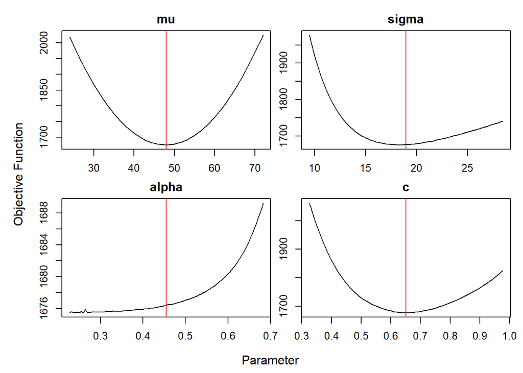

```r
s <- 1
negdmglik_model_unconstraint <- function(theta){
  mu <- theta[1]
  sigma <- theta[2]
  # alpha <- theta[3]
  alpha <- theta[3]
  c <- theta[4]

  lik1 <- sum(dnorm(R20_data,mean = mu, sd = sigma, log = TRUE))
  lik2 <- g2 * log(
    pnorm(dmg_inverse(l,alpha,l,c,s), mean = mu, sd = sigma) -
      pnorm(l, mean = mu, sd = sigma)
  )
  #lik2 <- 0
  lik3 <- sum(sapply(R20R100_data,dmglik,alpha,l,c,s,mu,sigma))
  lik4 <- sum(dnorm(R100_data,mean = mu, sd = sigma, log = TRUE))
  return(-lik1-lik2-lik3-lik4)
}

theta_opt <- optimout$par
theta_opt[3] <- expit(theta_opt[3])
optimCheck::optim_proj(theta_opt,
                       negdmglik_model_unconstraint ,xrng = .5,
                       xnames = c("mu","sigma","alpha","c"))
```

The plot shows that alpha does not seem to reach the mode.

## Real data analysis: control the other three parameter and only optimize alpha

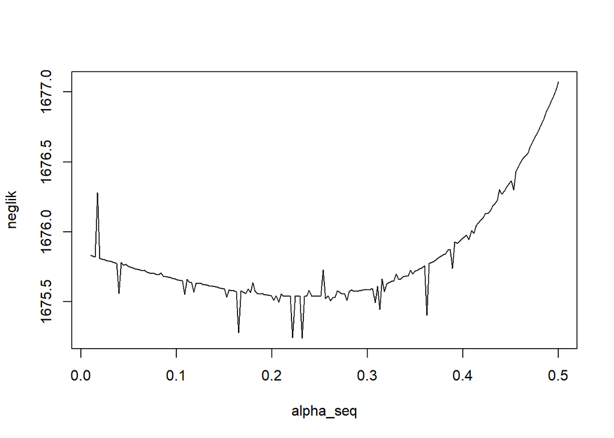

```r
## the only plot for alpha

negdmglik_alpha <- function(alpha){
  mu <- 47.9985218
  sigma <- 18.9804222
  # alpha <- theta[3]
  c <- 0.6515348

  lik1 <- sum(dnorm(R20_data,mean = mu, sd = sigma, log = TRUE))
  lik2 <- g2 * log(
    pnorm(dmg_inverse(l,alpha,l,c,s), mean = mu, sd = sigma) -
      pnorm(l, mean = mu, sd = sigma)
  )
  #lik2 <- 0
  lik3 <- sum(sapply(R20R100_data,dmglik,alpha,l,c,s,mu,sigma))
  lik4 <- sum(dnorm(R100_data,mean = mu, sd = sigma, log = TRUE))
  return(-lik1-lik2-lik3-lik4)
}

s <- 1
alpha_opt <- optimize(negdmglik_alpha,c(.01,.99))


alpha_seq <- seq(from = 0.01, to = 0.5, length =200)
plot(alpha_seq, sapply(alpha_seq,negdmglik_alpha),type = "l", ylab = "neglik")
```

```r
alpha_opt$minimum
```

```
## [1] 0.2415276
```

Although the likelihood not very smooth, but the plot does indicates that the mode is around 0.24.

# real data test

As all group3 has ystar (i.e., the damaged pieces), I tried to transform them back to the original y.

```r
test_data <- cbind(R20R100_data,
                   alpha45 = sapply(R20R100_data, dmg_inverse,0.45,l,0.65,s),
                   alpha25 = sapply(R20R100_data, dmg_inverse,0.25,l,0.65,s))
test_data
```

```
##        R20R100_data   alpha45   alpha25
##   [1,]     36.56108  48.12506  48.79442
##   [2,]     36.68973  48.15084  48.81575
##   [3,]     36.75250  48.16343  48.82618
##   [4,]     37.19432  48.25224  48.90010
##   [5,]     37.41119  48.29599  48.93673
##   [6,]     39.29546  48.68296  49.26600
##   [7,]     41.09937  49.07202  49.60546
##   [8,]     41.56787  49.17742  49.69860
##   [9,]     41.62275  49.18991  49.70965
##  [10,]     41.92525  49.25930  49.77122
##  [11,]     42.45173  49.38254  49.88100
##  [12,]     42.47436  49.38791  49.88580
##  [13,]     42.97845  49.50933  49.99443
##  [14,]     43.77578  49.70875  50.17380
```

[output cut: 132 more lines]

It seems that the result from $\alpha = 0.45$ and $\alpha = 0.25$ gives very similar y (the undamaged strength).

[figure not shown]

```r
alpha <- 0.25
c <- 0.65
y <- seq(from  = 0.01, to = 100, length = 200)
ystar <- dmg_model(y,alpha,l,c,s =1)
plot(y,ystar,type = 'l',lty = 1)
lines(y,dmg_model(y,alpha = 0.45,l,c,s =1),lty = 2)
legend("topleft", legend = c("ystar alpha = 0.45","ystar alpha = 0.25"),lty=1:2)
#abline(v = l)
abline(v = l/c)
```